# TreeClassification-HighRes-IndividualUser

Aitor Apaolaza

12/01/2016

*Copyright (c) 2015 The University of Manchester, UK.*

*Licenced under LGPL version 2.1. See LICENCE for details.*

*The IDInteraction Attention Classification was developed in the IDInteraction project, funded by the Engineering and Physical Sciences Research Council, UK through grant agreement number EP/M017133/1.*

*Author: Aitor Apaolaza*

## Initialisation and loading data

```
## [1] "All listed packages are already installed"
```

# Setup for the classification algorithm.

**Folder**: /home/aitor/Dropbox/UoM/IDInteractionCode/Rnotebooks

**Experiment**: dual_screen_free_experiment

**Source Videos**: high_quality

**Tracking system**: front_eyes_only

**Using the following list of participants**: P01.

**Using the following timelimit threshold to separate training and testing data**: 5.

Data for these participants will be read from the CSV files contained in the following folders:

/home/aitor/Dropbox/UoM/IDInteractionCode/Rnotebooks/resources/dual_screen_free_experiment/high_quality/attention/

/home/aitor/Dropbox/UoM/IDInteractionCode/Rnotebooks/resources/dual_screen_free_experiment/high_quality/front_eyes_only/

Loading data for participant P01

```
## [1] "Processing participant: P01"
## [1] "START of combineCSVsToDF()"
## [1] "END of combineCSVsToDF()"
## [1] "START of createFeatureDF()"
## [1] "END of createFeatureDF()"
```

## Training the tree classifier

Using the **rpart** library for the following formula:

**attentionName ~ boxHeight + boxRotation + boxArea + boxWidth + widthHeightRatio + boxYcoordRel**

Resulting model:

```
## n= 14535
##
## node), split, n, loss, yval, (yprob)
##       * denotes terminal node
##
##   1) root 14535 5822 tv (0.400550396 0.599449604)
##     2) boxYcoordRel>=0.2574095 3932 1312 ipad (0.666327569 0.333672431)
##       4) boxHeight< 15.7843 3128  683 ipad (0.781649616 0.218350384)
##         8) boxYcoordRel>=0.2638316 2333  368 ipad (0.842263180 0.157736820) *
##         9) boxYcoordRel< 0.2638316 795  315 ipad (0.603773585 0.396226415)
##          18) boxRotation>=-9.237835 319    1 ipad (0.996865204 0.003134796) *
##          19) boxRotation< -9.237835 476  162 tv (0.340336134 0.659663866)
##            38) boxRotation< -14.1574 156   36 ipad (0.769230769 0.230769231) *
##            39) boxRotation>=-14.1574 320   42 tv (0.131250000 0.868750000) *
##       5) boxHeight>=15.7843 804  175 tv (0.217661692 0.782338308) *
##     3) boxYcoordRel< 0.2574095 10603 3202 tv (0.301990003 0.698009997)
##       6) boxRotation>=-9.574995 5137 2190 tv (0.426318863 0.573681137)
##        12) boxYcoordRel>=0.2394781 1051  401 ipad (0.618458611 0.381541389) *
##        13) boxYcoordRel< 0.2394781 4086 1540 tv (0.376896721 0.623103279)
##          26) boxRotation>=12.21235 101   13 ipad (0.871287129 0.128712871) *
##          27) boxRotation< 12.21235 3985 1452 tv (0.364366374 0.635633626)
##            54) boxHeight< 15.47095 3346 1336 tv (0.399282726 0.600717274)
##             108) boxRotation>=-2.24953 402  140 ipad (0.651741294 0.348258706)
##               216) boxYcoordRel>=0.2207325 269   33 ipad (0.877323420 0.122676580) *
##               217) boxYcoordRel< 0.2207325 133   26 tv (0.195488722 0.804511278) *
##             109) boxRotation< -2.24953 2944 1074 tv (0.364809783 0.635190217) *
##            55) boxHeight>=15.47095 639  116 tv (0.181533646 0.818466354) *
##       7) boxRotation< -9.574995 5466 1012 tv (0.185144530 0.814855470) *
```

From the R manual for the Complexity Parameter Table for an Rpart Fit: *The cptable in the fit contains the mean and standard deviation of the errors in the cross-validated prediction against each of the geometric means.*

Matrix of information on the optimal prunings based on a complexity parameter.

```
##
## Classification tree:
## rpart(formula = formula, data = trainsetclass, method = "class")
##
## Variables actually used in tree construction:
## [1] boxHeight    boxRotation  boxYcoordRel
##
## Root node error: 5822/14535 = 0.40055
##
## n= 14535
##
##         CP nsplit rel error  xerror      xstd
## 1 0.224665      0   1.00000 1.00000 0.0101471
## 2 0.077980      1   0.77533 0.77825 0.0095919
## 3 0.021384      2   0.69735 0.70045 0.0093035
## 4 0.013054      4   0.65459 0.66867 0.0091701
## 5 0.012882      7   0.61405 0.62848 0.0089874
## 6 0.010477      8   0.60117 0.61731 0.0089338
## 7 0.010000     11   0.56630 0.60941 0.0088951
```

Visualisation of the Complexity Parameter Table. *A good choice of cp for pruning is often the leftmost value for which the mean lies below the horizontal line.*

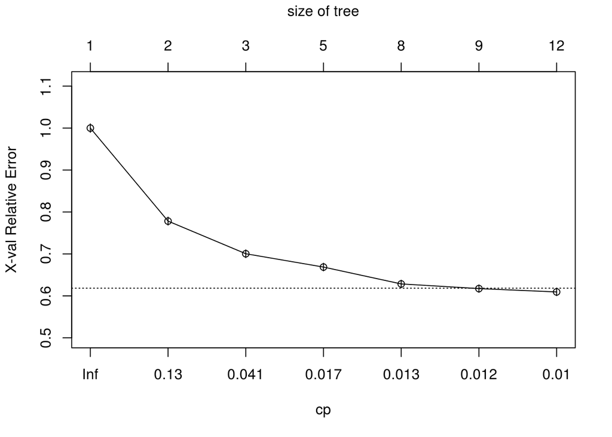

## Tree

### Summary of the tree

```
##
## Model formula:
## attentionName ~ boxHeight + boxRotation + boxArea + boxWidth +
##     widthHeightRatio + boxYcoordRel
##
## Fitted party:
## [1] root
## |   [2] boxYcoordRel >= 0.25741
## |   |   [3] boxHeight < 15.7843
## |   |   |   [4] boxYcoordRel >= 0.26383: ipad (n = 2333, err = 15.8%)
## |   |   |   [5] boxYcoordRel < 0.26383
## |   |   |   |   [6] boxRotation >= -9.23784: ipad (n = 319, err = 0.3%)
## |   |   |   |   [7] boxRotation < -9.23784
## |   |   |   |   |   [8] boxRotation < -14.1574: ipad (n = 156, err = 23.1%)
## |   |   |   |   |   [9] boxRotation >= -14.1574: tv (n = 320, err = 13.1%)
## |   |   [10] boxHeight >= 15.7843: tv (n = 804, err = 21.8%)
## |   [11] boxYcoordRel < 0.25741
## |   |   [12] boxRotation >= -9.57499
## |   |   |   [13] boxYcoordRel >= 0.23948: ipad (n = 1051, err = 38.2%)
## |   |   |   [14] boxYcoordRel < 0.23948
## |   |   |   |   [15] boxRotation >= 12.21235: ipad (n = 101, err = 12.9%)
## |   |   |   |   [16] boxRotation < 12.21235
## |   |   |   |   |   [17] boxHeight < 15.47095
## |   |   |   |   |   |   [18] boxRotation >= -2.24953
## |   |   |   |   |   |   |   [19] boxYcoordRel >= 0.22073: ipad (n = 269, err = 12.3%)
## |   |   |   |   |   |   |   [20] boxYcoordRel < 0.22073: tv (n = 133, err = 19.5%)
## |   |   |   |   |   |   [21] boxRotation < -2.24953: tv (n = 2944, err = 36.5%)
## |   |   |   |   |   [22] boxHeight >= 15.47095: tv (n = 639, err = 18.2%)
## |   |   [23] boxRotation < -9.57499: tv (n = 5466, err = 18.5%)
##
## Number of inner nodes:    11
## Number of terminal nodes: 12
```

### Visualisation of the tree

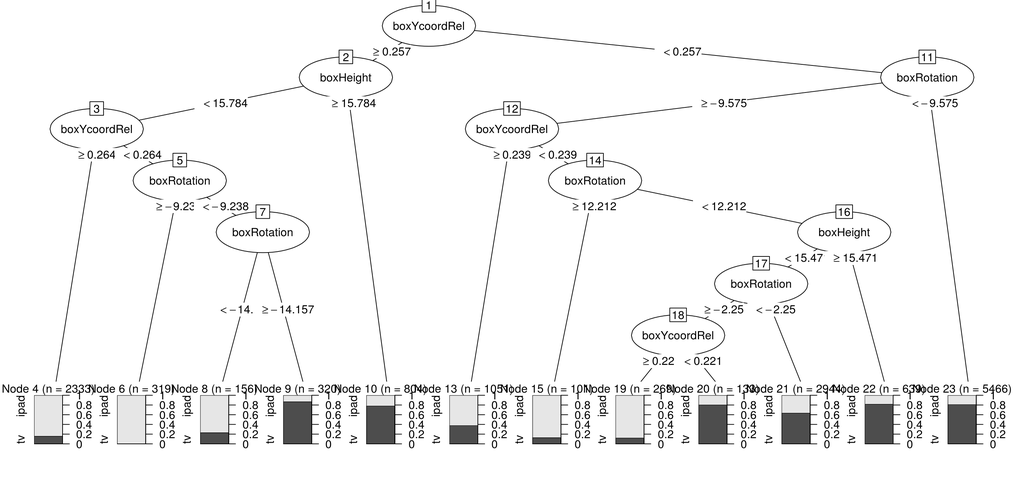

Tree classifier plot

## Error metrics analysis

Confusion matrix from the application of the tree predictor to the testing set of data.

```
##       predclass
##         ipad    tv
##   ipad 11433  2832
##   tv    6914 10145
```

### Error metrics based on prediction of attention to the iPad.

True negatives: 10145

True positives: 11433

**Error-rate**: the proportion of the incorrectly classified examples -> (fp+fn)/(tp+tn+fp+tn)

**31.1135232**

**Accuracy**: the proportion of the correctly classified examples -> (tp+tn)/(tp+tn+fp+tn)

**68.8864768**

As the number of instances of the response variable is not balanced (there are many more instances with false than true) the accuracy is not a good indicator. Other cost sensitive measures are reported here. -> cost sensitive measures

**Precision**: positive predicted value (PPV) -> tp/(tp+fp), a measure of exactness

**80.1472135**

**Recall/Sensitivity**: true positive recognition rate -> tp/(tp+fn), a measure of completeness

**62.3153649**

**Specificity**: true negative recognition rate -> tn/(tn+fp)

**78.1767743**

**F measure**: the balance between precision and recall -> 2*tp/(2*tp+fp+fn)

**70.115295**

# ERROR MEASURES INLINE COPY

P01 **31.1135232** **68.8864768** **80.1472135** **62.3153649** **78.1767743** **70.115295**

### Error metrics based on prediction of attention to the TV.

True negatives: 11433

True positives: 10145

**Error-rate**: the proportion of the incorrectly classified examples -> (fp+fn)/(tp+tn+fp+tn)

**31.1135232**

**Accuracy**: the proportion of the correctly classified examples -> (tp+tn)/(tp+tn+fp+tn)

**68.8864768**

As the number of instances of the response variable is not balanced (there are many more instances with false than true) the accuracy is not a good indicator. Other cost sensitive measures are reported here. -> cost sensitive measures

**Precision**: positive predicted value (PPV) -> tp/(tp+fp), a measure of exactness

**59.4700744**

**Recall/Sensitivity**: true positive recognition rate -> tp/(tp+fn), a measure of completeness

**78.1767743**

**Specificity**: true negative recognition rate -> tn/(tn+fp)

**62.3153649**

**F measure**: the balance between precision and recall -> 2*tp/(2*tp+fp+fn)

**67.5522706**